# Ford GoBike Data System: Data Exploration

## Introduction

This document explores a dataset that includes information about individual rides made in a bike-sharing system covering the greater San Francisco Bay area. it covers the first quarter of 2020. [Download here](https://www.lyft.com/bikes/bay-wheels/system-data), you'll find Bay Wheels's trip data for public use.

### What is/are the main feature(s) of interest in your dataset?

- When are most trips taken in terms of time of day, day of the week, or month of the year?
- How long does the average trip take?
- Does the above depend on if a user is a subscriber or customer?

## Univariate Exploration

```python
# import all packages and set plots to be embedded inline
import numpy as np
import pandas as pd
import matplotlib.pyplot as plt
import seaborn as sb
import calendar
import datetime

%matplotlib inline
# suppress warnings from final output
import warnings
warnings.simplefilter("ignore")
```

### Bike Trip Duration

We notice from the trip duration distribution that in most of the bike trips (40,000), the bike is rented for about 5-10 minutes. Moreover, the average renting time according to the statistic summary is 12 minutes.

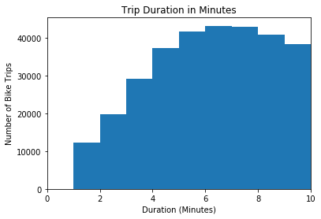

```python
binsize = 1
bins = np.arange(0, df.duration_min.max()+binsize, binsize)
plt.hist(data = df, x = 'duration_min', bins=bins);
#plt.ylim(0,100)
plt.xlim(0,10)
plt.title("Trip Duration in Minutes")
plt.xlabel('Duration (Minutes)')
plt.ylabel('Number of Bike Trips');
```

### Bike rides in each month

It appears that February has the most brike rides which was expected with slightly warmer weather and the Valentine's Day (couple going out on trips). However, the trips has drastically decreased by March which is also expected since the break of covid–19.

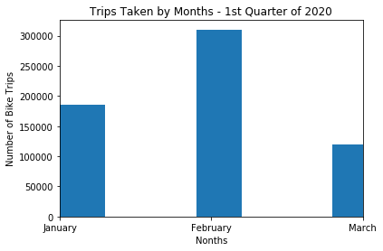

```python
plt.hist(data = df, x = 'month');
plt.xlim(0,2)
plt.title("Trips Taken by Months - 1st Quarter of 2020")
plt.xlabel('Nonths')
plt.ylabel('Number of Bike Trips');
```

### Bike trips by day of week

The bar chart shows that from Wednesday to Friday has the most ride trips number. Interestingly, the weekend has the least number! This suggest that people rent bikes for working days (i.e. taking rides to work this justify the 10 mins trip.)

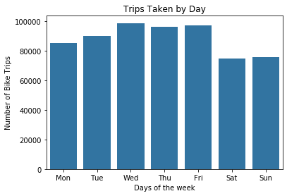

```python
weekday = ['Mon', 'Tue', 'Wed', 'Thu', 'Fri', 'Sat', 'Sun']
sb.countplot(data=df, x='dayofweek',color=sb.color_palette()[0] ,order=weekday);
plt.ylabel('Number of Bike Trips')
plt.xlabel('Days of the week')
plt.title('Trips Taken by Day')
plt.show()
```

### Bike trips by hours

The peak time or the top two hours is 5:00 pm followed by 8:00 am. Moreover, from the distribiution the top two hours and the adjesant hours has large number of bike rides! This also proves that the users are renting bikes during working hours (i.e. renting bikes for commuting from/to work).

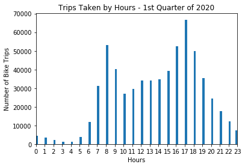

```python
binsize = 0.25
bins = np.arange(0, df.start_hour.max()+binsize, binsize)
plt.hist(data = df, x = 'start_hour', bins=bins)
plt.title("Trips Taken by Hours - 1st Quarter of 2020")
plt.xlim(0,23)
plt.xticks([0,1,2,3,4,5,6,7,8,9,10,11,12,13,14,15,16,17,18,19,20,21,22,23])
plt.xlabel('Hours')
plt.ylabel('Number of Bike Trips');
```

### Bike trip distances (km)

The distribution of the trip distance shows that most of the rides takes 1km. the second most is less than 1km. according to the statistic the average trip distance is 1.93km with 25% it takes 0.92km and 57% of the rides it takes 2.63km.

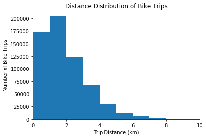

```python
binsize = 1
bins = np.arange(0, df.distance_km.max()+binsize, binsize)
plt.hist(data = df, x = 'distance_km', bins=bins)
plt.title("Distance Distribution of Bike Trips")
plt.xlim(0,10)
plt.xlabel('Trip Distance (km)')
plt.ylabel('Number of Bike Trips');
```

### The rental access methods used most of the bike trips

92.33% of the bike rental methods are by app and only 7.67% are rented by clippers (transit card).

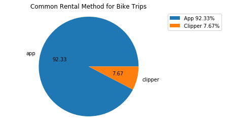

```python
labels = ['App 92.33%','Clipper 7.67%']
plt.pie(common_method,labels=common_method.index, autopct='%.2f');
plt.axis('equal')
plt.title('Common Rental Method for Bike Trips')
plt.legend(labels, bbox_to_anchor=(1.3,1.0), loc="upper right")
plt.show()
```

### User types

86.11% of the users are subscribers while 13.88% of them are customer!

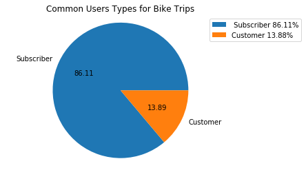

```python
labels = [' Subscriber 86.11%','Customer 13.88%']
plt.pie(common_users,labels=common_users.index, autopct='%.2f');
plt.axis('equal')
plt.title('Common Users Types for Bike Trips')
plt.legend(labels, bbox_to_anchor=(1.3,1.0), loc="upper right")
plt.show()
```

## Bivariate Exploration

### Relationship between user types and time duration

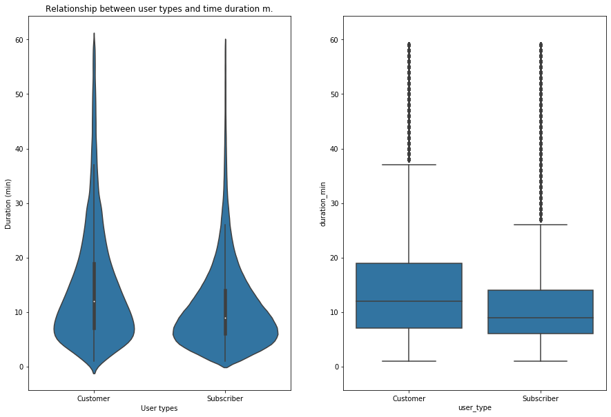

```python
# base_color = sb.color_palette()[0]
# s=sb.violinplot(data = cond, y = 'duration_min', x =  'user_type' , color=base_color)

plt.figure(figsize = [15, 10])
base_color = sb.color_palette()[0]

# left plot: violin plot
plt.subplot(1, 2, 1)
ax1 = sb.violinplot(data = cond, x = 'user_type', y = 'duration_min', color = base_color)

# right plot: box plot
plt.subplot(1, 2, 2)
sb.boxplot(data = cond, x = 'user_type', y = 'duration_min', color = base_color)
plt.ylim(ax1.get_ylim()) # set y-axis limits to be same as left plot
ax1.set(xlabel='User types',ylabel='Duration (min)', title='Relationship between user types and time duration m.')


plt.show()
```

### Relationship between user types and months 1st quarter of 2020

Both subscribers and customer hit the peak in february then decreased drastically in march.

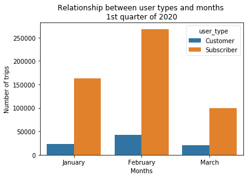

```python
ax = sb.countplot(data = df, x = 'month', hue = 'user_type', order=['January','February','March'])
ax.legend(loc = 1, ncol = 1, framealpha = 0.5, title = 'user_type')
ax.set(xlabel='Months',ylabel='Number of trips', title='Relationship between user types and months \n1st quarter of 2020')

plt.show()
```

### Relationship between user types and days of week

We notice here that subscribers are more likely to take rides in general since they represent 86%, hence, it affects the distribution of the trips by days. specifically, subscribers usage in the week days Wednesday and Friday (for work) and decreased by fraction in the weekends. Meanwhile, the customers are the less consuming/renting rides and there is a slight increasing at the weekends.

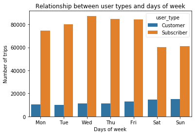

```python
ax = sb.countplot(data = df, x = 'dayofweek', hue = 'user_type', order=weekday)
ax.legend(loc = 1, ncol = 1, framealpha = 0.5, title = 'user_type')
ax.set(xlabel='Days of week',ylabel='Number of trips', title='Relationship between user types and days of week')
plt.show()
```

### Relationship between user types and time of day

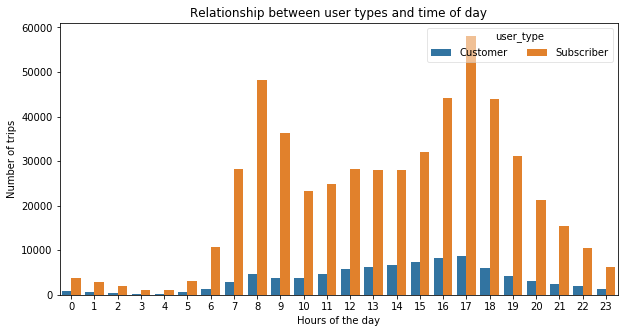

```python
plt.figure(figsize = [10, 5])
ax = sb.countplot(data = df, x = 'start_hour', hue = 'user_type')
ax.legend(loc = 1, ncol = 3, framealpha = 0.5, title = 'user_type')
ax.set(xlabel='Hours of the day',ylabel='Number of trips', title='Relationship between user types and time of day')
plt.show()
```

### Relationship between user types and rental methods

Both subscribers and customers rented bikes by app, however, both have a relatively small number of trips rented using clippers.

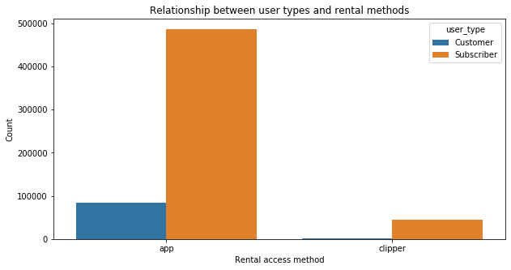

```python
plt.figure(figsize = [10, 5])
s=sb.countplot(data = df, x = 'rental_access_method', hue = 'user_type')
s.set(xlabel='Rental access method',ylabel='Count', title='Relationship between user types and rental methods')
plt.show()
```

## Multivariate Exploration

The main thing I want to explore in this part of the analysis is how the three vatiables date-time (Months, Days, Hours), user type, duration (min) play into the relationship with trips count. Now we can answer the following

- When are most trips taken in terms of time of day, day of the week, or month of the year?
- How long does the average trip take?
- Does the above depend on if a user is a subscriber or customer?

### Trips duration by user type and rental method

Both types of group used app as rental method for the trip more over than clipper (transit card). it does not seem that the rental method is effective on the other two. In trips type of users with duration affect the result, i.e. when its a customer he/she tends to have more trip duration.

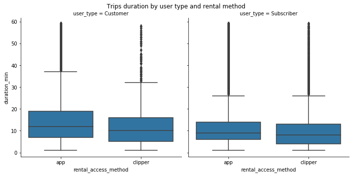

```python
g = sb.FacetGrid(data = cond, col = 'user_type', height=5)
g.map(sb.boxplot, 'rental_access_method', 'duration_min')
plt.subplots_adjust(top=0.9)
g.fig.suptitle('Trips duration by user type and rental method')
plt.show()
```

### Trips taken in terms of time of day, day of the week, or month of the year

**The following plotted visuals answer our main question/topic**

### Trips taken in terms of day of the week and user type

We notice here the trip duration for subscribers has consistency throughout the week days with averaage duration 5-10 minutes. However, the trip duration for customers is more than with the subscribers for all days especially during weekends. As we saw earlier in bivariate exploration and the relationship between trip duration and user types. The customers tend to take long trips on weekends compared to weekdays.

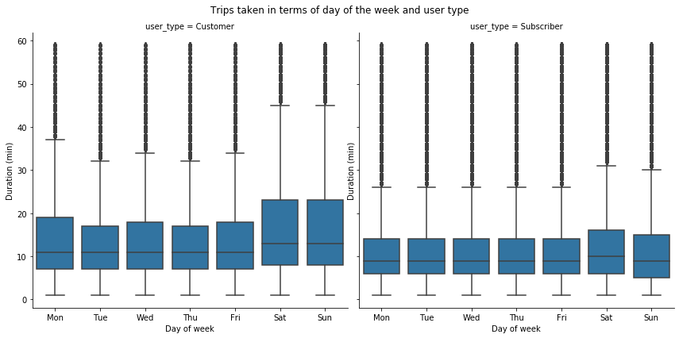

```python
g = sb.FacetGrid(data = cond, col = 'user_type', height=6)
g.map(sb.boxplot, 'dayofweek', 'duration_min',order=weekday)
g.set(xlabel='Day of week', ylabel='Duration (min)')
plt.subplots_adjust(top=0.9)
g.fig.suptitle('Trips taken in terms of day of the week and user type')
plt.show()
```

### Trips taken by months and user type

The customers still have the higher trip duration, however, there is consistency in time duration throughout the months...

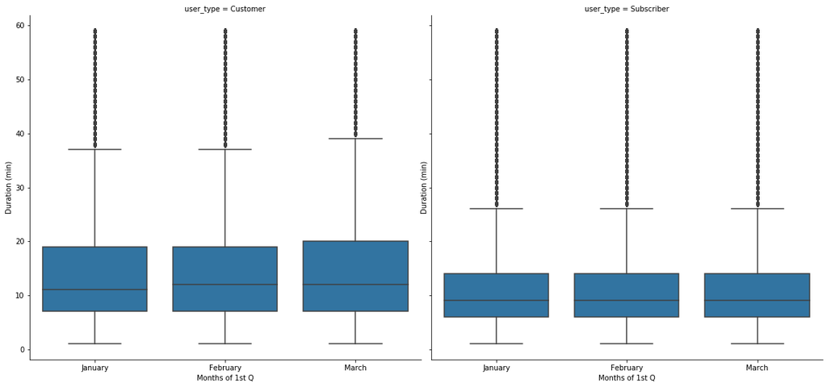

```python
g = sb.FacetGrid(data = cond, col = 'user_type', height=8)
g.map(sb.boxplot, 'month', 'duration_min', order=['January','February','March'])
g.set(xlabel='Months of 1st Q', ylabel='Duration (min)')
plt.subplots_adjust(top=0.9)
g.fig.suptitle='Trips taken by months \n and user type'
plt.show()
```

### Talk about some of the relationships you observed in this part of the investigation. Were there features that strengthened each other in terms of looking at your feature(s) of interest?

I extended my investigation of the three vatiables date-time (Months, Days, Hours), user type, trip duration (min) in this section by looking at the impact of it on the trips.. To answer the following

- When are most trips taken in terms of time of day, day of the week, or month of the year?
- How long does the average trip take?
- Does the above depend on if a user is a subscriber or customer? The findings was just as we expected.

## References

[1] https://gist.github.com/rochacbruno/2883505  
[2] https://pandas.pydata.org/pandas-docs/stable/reference/api/pandas.DataFrame.reset_index.html  
[3] https://news.google.com/covid19/map?hl=en-US&mid=%2Fg%2F11g6njkk2y&gl=US&ceid=US%3Aen  
[4] Udacity - https://udacity.com/  
[5] YouTube Tutorials - https://www.youtube.com/  
[6] stackoverflow - https://stackoverflow.com  
[7] Title positioning error - suptitle - https://stackoverflow.com/questions/52096050/seaborn-title-position